# Evaluating the impact of lexico-grammatical tagging systems on multidimensional analysis

### Dimension 5

It’s hard to see much in this plot, as Biberpy’s count of conjuncts seems to be absurdly high (also very high for BiberPlus).

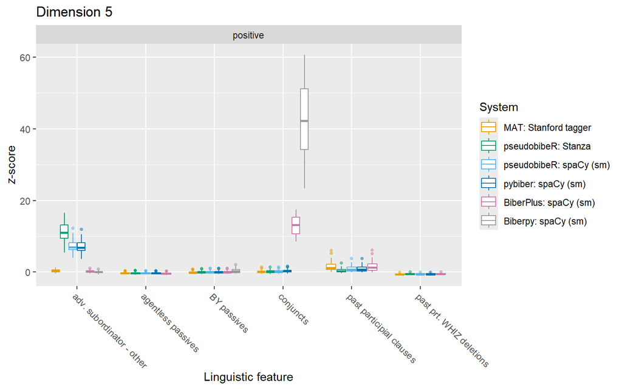

```r
comparison |>
  filter(dim5 != 0) |>
  mutate(contribution = ifelse(dim5 > 0, "positive", "negative")) |>
  ggplot(aes(x = `Linguistic feature`, y = zscore, colour = system)) +
  geom_boxplot(outlier.size = 1, outlier.alpha = .5) + # linewidth = .4, outlier.size = 1
  theme(axis.text.x = element_text(angle = -45, hjust = 0), axis.title.y = element_markdown()) +
  facet_grid(cols = vars(contribution), scales = "free_x", space = "free") +
  scale_colour_oi(order = c(1, 3, 2, 5, 7, 8, 4, 6, 9)) +
  labs(y = "<i>z</i>-score", colour = "System", title = "Dimension 5")
```

For the plot’s sake, let’s remove Biberpy’s count of conjuncts from the picture:

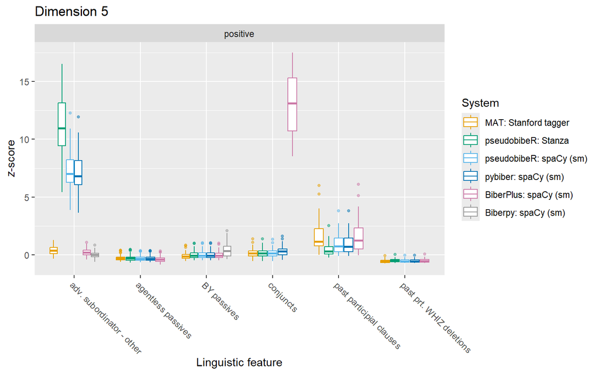

```r
dim5_comp <- comparison |>
  filter(dim5 != 0) |>
  filter(!(feature_pseudobiber == "f_45_conjuncts" & system == "Biberpy: spaCy (sm)")) |>
  mutate(contribution = ifelse(dim5 > 0, "positive", "negative")) |>
  ggplot(aes(x = `Linguistic feature`, y = zscore, colour = system)) +
  geom_boxplot(outlier.size = 1, outlier.alpha = .5) + # linewidth = .4, outlier.size = 1
  theme(axis.text.x = element_text(angle = -45, hjust = 0), axis.title.y = element_markdown()) +
  facet_grid(cols = vars(contribution), scales = "free_x", space = "free") +
  scale_colour_oi(order = c(1, 3, 2, 5, 7, 8, 4, 6, 9)) +
  labs(y = "<i>z</i>-score", colour = "System", title = "Dimension 5")
dim5_comp
```

With filtering, only 3 out of 6 features are used. The following are discarded:

- 18 (BY passives)
- 26 (past participial clauses)
- 38 (adv. subordinator - other)

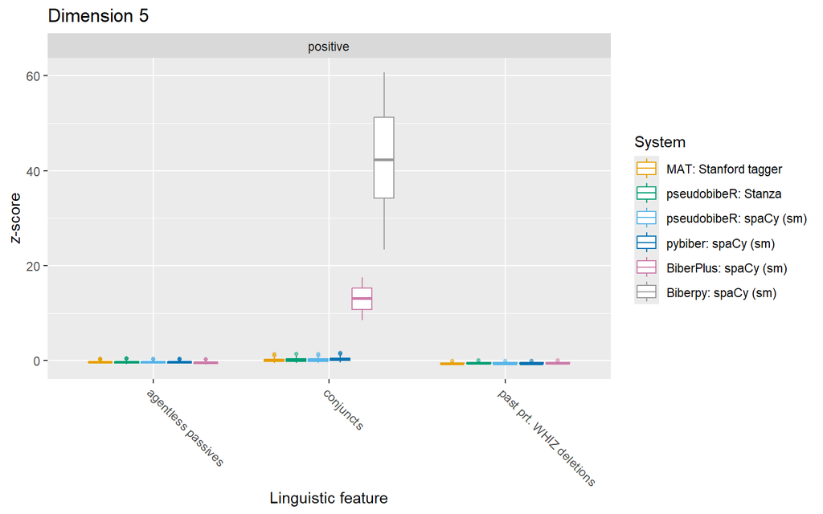

```r
comparison |>
  filter(dim5 != 0,
         mean > 1) |>
  mutate(contribution = ifelse(dim5 > 0, "positive", "negative")) |>
  ggplot(aes(x = `Linguistic feature`, y = zscore, colour = system)) +
  geom_boxplot(outlier.size = 1, outlier.alpha = .5) +
  theme(axis.text.x = element_text(angle = -45, hjust = 0), axis.title.y = element_markdown()) +
  facet_grid(cols = vars(contribution), scales = "free_x", space = "free") +
  scale_colour_oi(order = c(1, 3, 2, 5, 7, 8, 4, 6, 9)) +
  labs(y = "<i>z</i>-score", colour = "System", title = "Dimension 5")
```

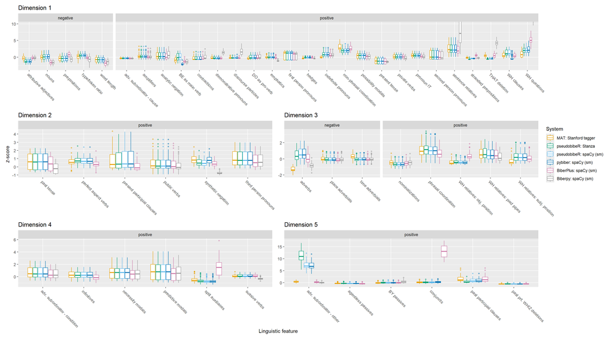

```r
design <- "
  11
  23
  45
"

dim1_comp + dim2_comp + dim3_comp + dim4_comp + dim5_comp +
  plot_layout(guides = "collect",
              axis_titles = "collect",
              design = design)
```

```r
# 11x11
```

## Speed comparisons

Speed comparisons favour pybiber over pseudobibeR. All Python systems using spaCy are almost equally fast. Using the GPU instead of the CPU speeds spaCy up considerably.

spaCy’s transformer model (which requires GPU usage) is a lot slower than its more lightweight models. Similarly, Stanza itself, which is also transformer-based, takes slightly over an hour to annotate the whole corpus.

```r
speed_pseudobiber <- read_csv("output_pseudobiber/quotes_nonquotes_corpus/spacy_timings_ttr100.csv") |>
  mutate(program = "pseudobibeR", .before = model,
         time_minutes = round(time_sec / 60)) |>
  select(-time_sec)

speed_pybiber <- read_csv("output_pybiber/timing_results.csv") |>
  mutate(program = "pybiber", .before = model,
         time_minutes = round(time_seconds / 60, 2)) |>
  select(-time_seconds)

speed_biberplus <- read_csv("output_biberplus/timing_results_no_gpu.csv") |>
  mutate(program = "BiberPlus", .before = model,
         time_minutes = round(time_seconds / 60, 2)) |>
  select(-time_seconds)

speed_biberplus_gpu <- read_csv("output_biberplus/timing_results.csv") |>
  mutate(program = "BiberPlus (GPU)", .before = model,
         time_minutes = round(time_seconds / 60, 2)) |>
  select(-time_seconds)

speed_biberpy <- read_csv("output_biberpy/timing_results.csv") |>
  mutate(program = "Biberpy", .before = model,
         model = str_remove(model, "en_core_web_"),
         time_minutes = round((time_seconds + 67) / 60, 2)) |> # add runtime of biber-dym.py
  select(-time_seconds)

speed_stanza <- read_csv("output_stanza/timing_results.csv") |>
  mutate(program = "Stanza", .before = model,
         model = "combined model",
         time_minutes = round(time_seconds / 60, 2)) |>
  select(-time_seconds)

speeds <- bind_rows(speed_pseudobiber, speed_pybiber, speed_biberplus, speed_biberplus_gpu, speed_biberpy, speed_stanza)
speeds
```

| program | time_minutes | model |
| --- | --- | --- |
| pseudobibeR | 36.00 | sm |
| pseudobibeR | 37.00 | md |
| pseudobibeR | 37.00 | lg |
| pybiber | 14.03 | sm |
| pybiber | 14.79 | md |
| pybiber | 14.80 | lg |
| pybiber | 89.76 | trf |
| BiberPlus | 13.27 | sm |
| BiberPlus (GPU) | 6.51 | sm |
| Biberpy | 14.61 | sm |

[output cut: 1 more lines]

## Footnotes

[^1]: Thanks to the anonymous reviewer who pointed out that our original model (`Dimension1 ~ corpus + subcorpus + corpus:subcorpus + method + (1|doc_id)`) was missing the random effect of individual documents and – possibly – the interaction of model and subcorpus.